## Assignment 2

- Replace the text YOUR NAME HERE in the YAML section with your name.
- Execute the code in the chunk below to read in the Lake Monona data. *(Note: this data set is different than that used in lecture.)*
  - If there is an error, check to see if there is a `data` directory two directories up that contains the data file.
- Post questions on our Piazza site, visit the Learning Center, or attend office hours if you have questions.

### 1

The following code makes a histogram of the `duration` variable in the Lake Monona data set.

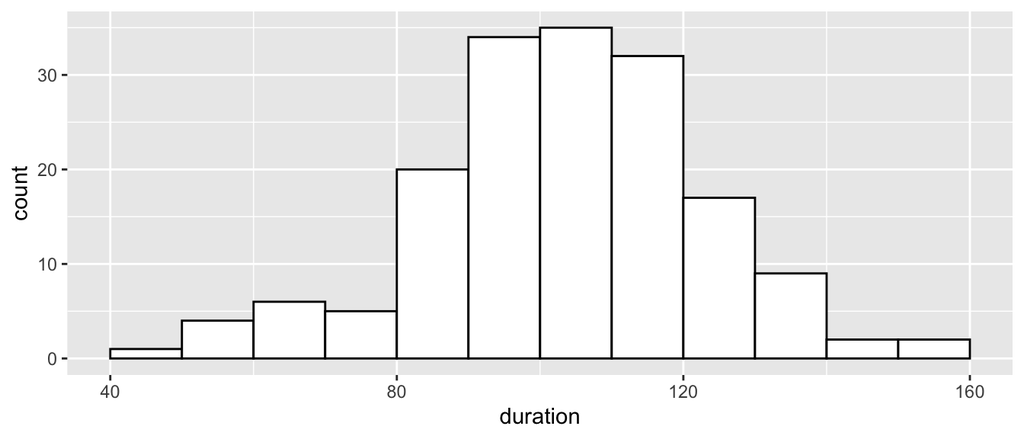

```r
ggplot(monona, aes(x=duration)) +
  geom_histogram(boundary=0, binwidth=10, color="black", fill="white")
```

Approximately how many winters had between 40 to 70 days where Lake Monona was at least 50% covered with ice?

### Response

11

### 2

Modify the code below so that in the resulting plot:

- one of the bins is centered at 70 days
- the width of each bin is 5 days
- the color of the interior of the bars is “forestgreen”
- the color outlining the bars is “darkviolet”
- the x label says “Days Closed with Ice”
- the y label says “Total”
- there is a title with words of your choosing that describe the figure

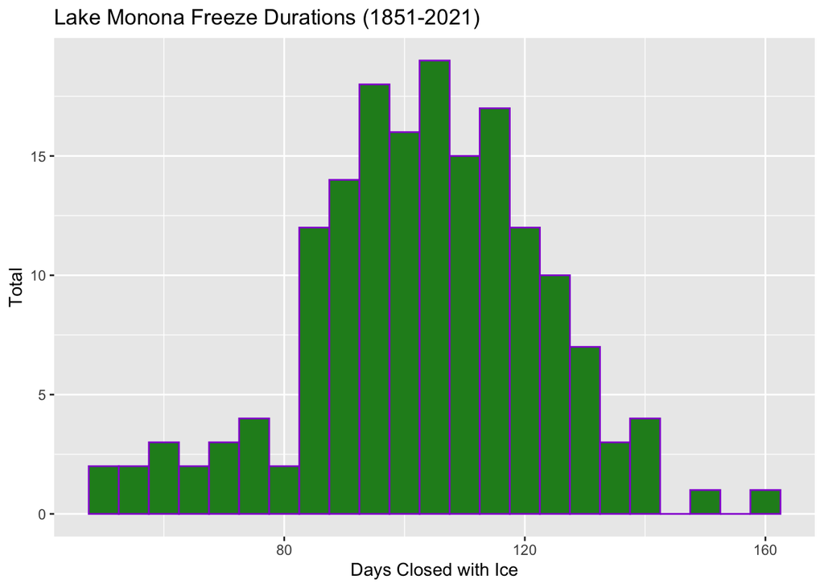

```r
## modify this code
ggplot(monona, aes(x=duration)) +
  geom_histogram(center=70, binwidth=5, color="darkviolet", fill="forestgreen") +
  xlab("Days Closed with Ice") +
  ylab("Total") +
  ggtitle("Lake Monona Freeze Durations (1851-2021)")
```

### 3

Create a line plot with `duration` on the y axis and `year1` on the x axis. Add a blue smooth curve and a straight red line which estimate the trends. Modify axis labels and add an appropriate title.

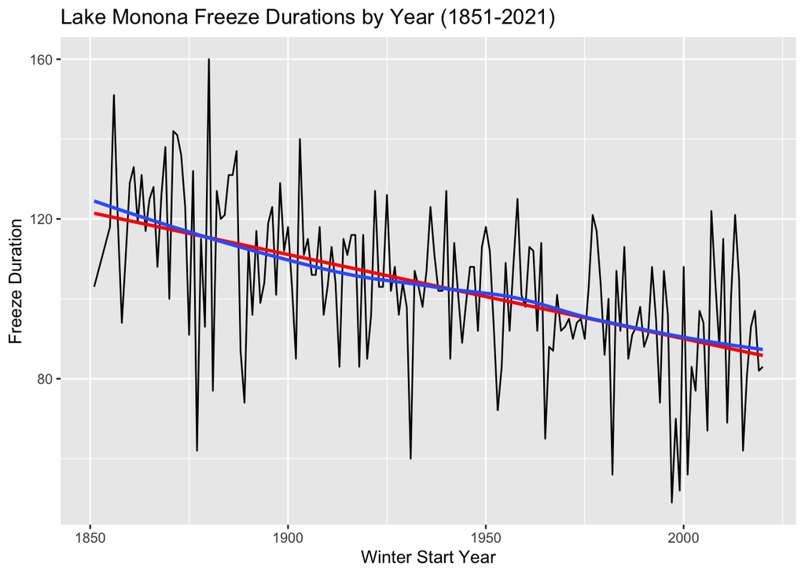

```r
ggplot(data=monona, aes(x=year1, y=duration)) +
  geom_line() +
  geom_smooth(method="lm", color="red", se=FALSE) +
  geom_smooth(se=FALSE) +
  xlab("Winter Start Year") +
  ylab("Freeze Duration") +
  ggtitle("Lake Monona Freeze Durations by Year (1851-2021)")
```

- Compare the curve and the straight line; does the curve differ from the straight line in an important manner?
- To the nearest five days, about how long was Lake Monona closed with ice in a typical year near 1875 (i.e., what is the approximate value of the smooth curve or straight line around 1875)?
- To the nearest five days, about how long was Lake Monona closed with ice in a typical year near 2000 (i.e., what is the approximate value of the smooth curve or straight line around 2000)?

### Response

1. Both models depict a decreasing, relatively linear relationship between year and the freeze duration of Lake Monona. The linear model does not differ from the curved model in an important manner. The largest differences between the two models occur from 1851 to around 1865.
2. Lake Monona was closed for about 115 days in a typical winter near the year 1875.
3. In 2000 and the winters close to it, we typically see Lake Monona closed for a total of 90 days over the course of the winter.

### 4

The next chunk of code adds columns to the `monona` data set which contain the fitted values ($\hat{y}_i$ in the notation of the lecture notes) and the residuals after fitting a straight line simple regression model to the data. You do not need to examine or understand this code chunk.

```r
## Fit the model
fit = lm(duration ~ year1, data = monona)

## Add fitted values and residuals to the data set
monona = monona %>%
  mutate(fitted = fitted(fit),
         residuals = residuals(fit))
```

Make a plot of the residuals versus year1. Add a horizontal line with an intercept at zero. *(See example from lecture using `geom_hline()`)*. Add a smooth curve to this residual plot as well.

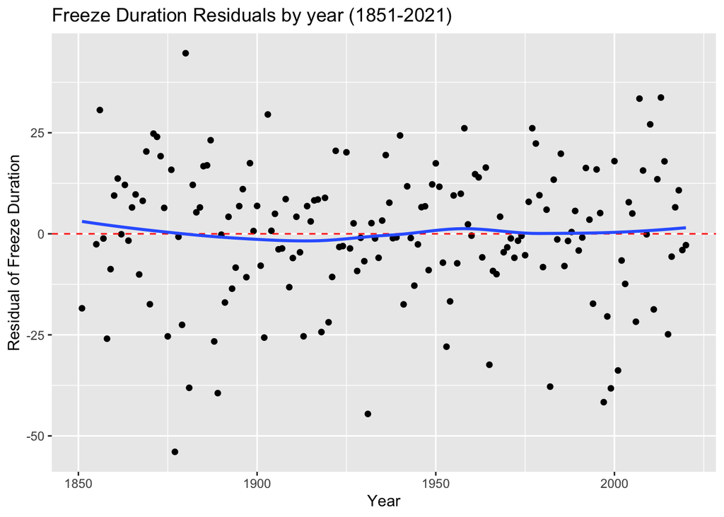

```r
ggplot(data=monona, aes(x=year1, y=residuals)) +
  geom_point() +
  geom_hline(yintercept=0, color="red", linetype="dashed") +
  geom_smooth(se=FALSE) +
  xlab("Year") +
  ylab("Residual of Freeze Duration") +
  ggtitle("Freeze Duration Residuals by year (1851-2021)")
```

Using the informal interpretation discussed in lecture, what evidence from the residual plot indicates that a straight-line simple regression model for the duration that Lake Monona is frozen versus time is an adequate model?

### Response

The fact that the residual plot shows a high amount of randomness/inconsistency tells us that a liear model would be an appropriate fit.

### 5

The next chunk of code adds a variable `winter_day` to the `monona` data set which counts the number of days after the previous June 30 on which Lake Monona first freezes. You do not need to examine or understand this code.

```r
## add winter_day = #days of first freeze after June 30
monona = monona %>%
  mutate(winter_day = as.numeric(
    first_freeze - ymd(str_c(year1,"-06-30"))))
```

Make a histogram of this variable with bins of width 5 centered and one bin centered at 154 (which corresponds to December 1). Select different colors to shade the interior and the boundaries of the bars. Add appropriate axis labels and a plot title.

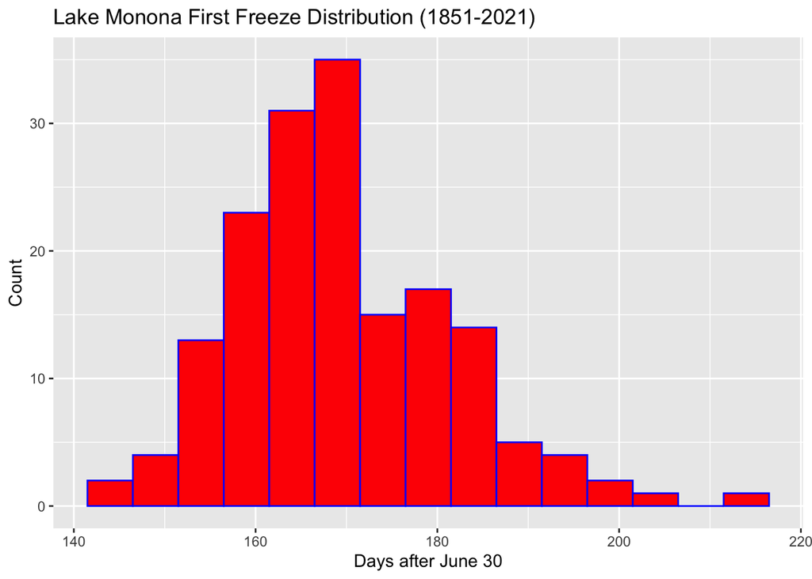

```r
## Make the histogram
ggplot(monona, aes(x=winter_day)) +
  geom_histogram(center=154, binwidth=5, color="blue", fill="red") +
  xlab("Days after June 30") +
  ylab("Count") +
  ggtitle("Lake Monona First Freeze Distribution (1851-2021)")
```

### 6

Recreate the plot from the previous problem, but modify scale of the x axis so that the axis is labeled with the dates Dec 1, Dec 16, Dec 31, Jan 15, Jan 30 at the values 154, 169, 184, 199, 214. You will use the function `scale_x_continuous()` to change the scale of the x axis. *(Hint: See an example changing the scale of the y axis in lecture 5)*.

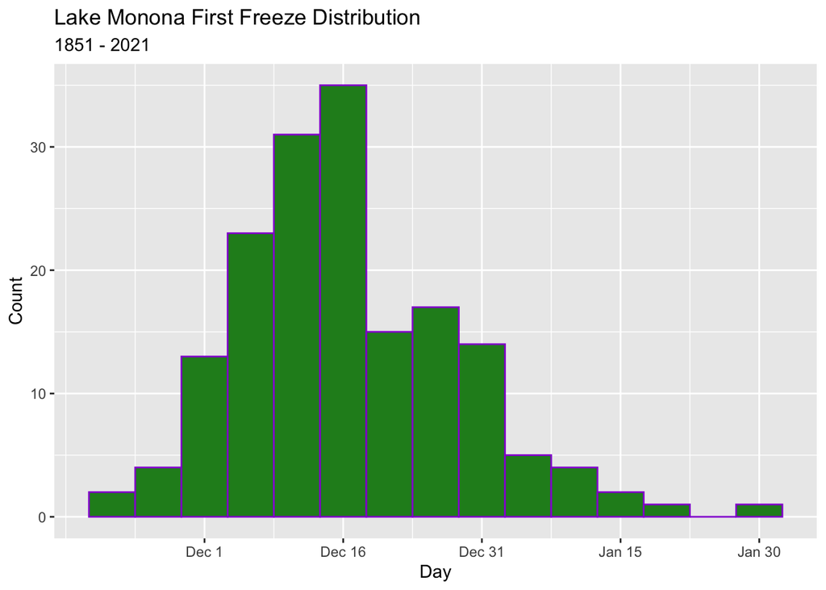

```r
ggplot(monona, aes(x = winter_day)) +
  geom_histogram(binwidth = 5, center = 154, color = "darkviolet", fill = "forestgreen") +
  scale_x_continuous(breaks = seq(154,214,by=15),
                     labels = c("Dec 1", "Dec 16", "Dec 31", "Jan 15", "Jan 30")) +
  xlab("Day") +
  ylab("Count") +
  ggtitle("Lake Monona First Freeze Distribution",
          subtitle = "1851 - 2021")
```

### 7

The next chunk of code reads in the exoplanet data discussed in the course notes, reduces the data set to a few variables, renames these, and drops observations with missing masses. You do not need to read or comment on this code chunk.

```r
## Note: the file begins with 100 comment lines which we skip
exo = read_csv("../../data/exoplanets_default_2021-06-15.csv", skip = 100) %>%
  select(pl_name, hostname, discoverymethod, pl_bmasse) %>%
  rename(planet = pl_name,
         star = hostname,
         method = discoverymethod,
         mass = pl_bmasse) %>%
  drop_na(mass)
```

The following code chunk makes a boxplot of the planet masses (units are in Earth masses, so 10 is ten times the mass of Earth) versus the method of discovery.

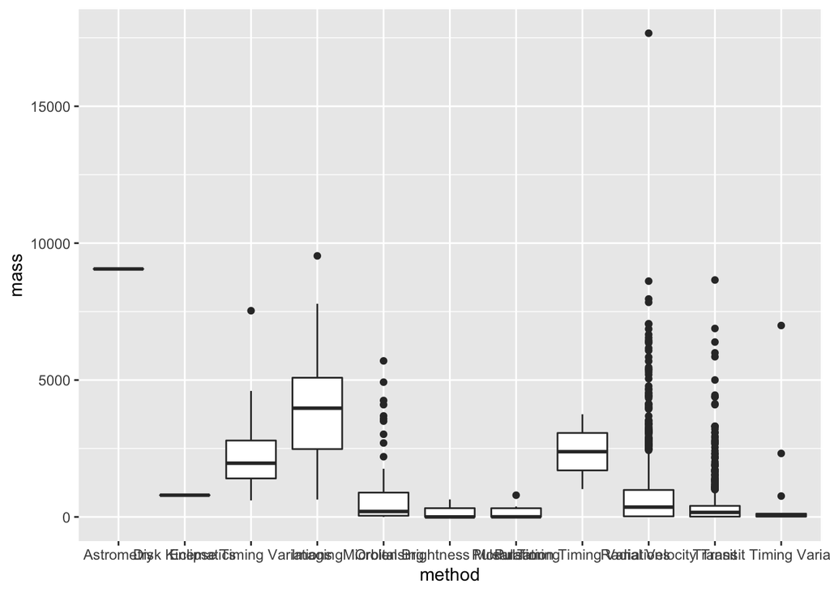

```r
ggplot(exo, aes(x = method, y = mass)) +
  geom_boxplot()
```

What are some faults that this basic plot has?

### Response

One of the most noticable faults of this plot is the labeling of the x-axis, it is near impossible to read what some of the values indicate. Another fault of this plot is the scaling of the y-axis. There are a few outliers that are skewing the data dramatically to the right. Also, some of the methods, such as the first two, do not have enough data points to warrant plotting on the graph (only the median is plotted).

The next code chunk adds several lines of code. Explain the effect that each additional line highlighted with a comment does to the plot. Try running the code with the indicated lines commented out or seek information from R Studio help, the *R for Data Science* textbook, or a Google search about each command and argument to understand what it does.

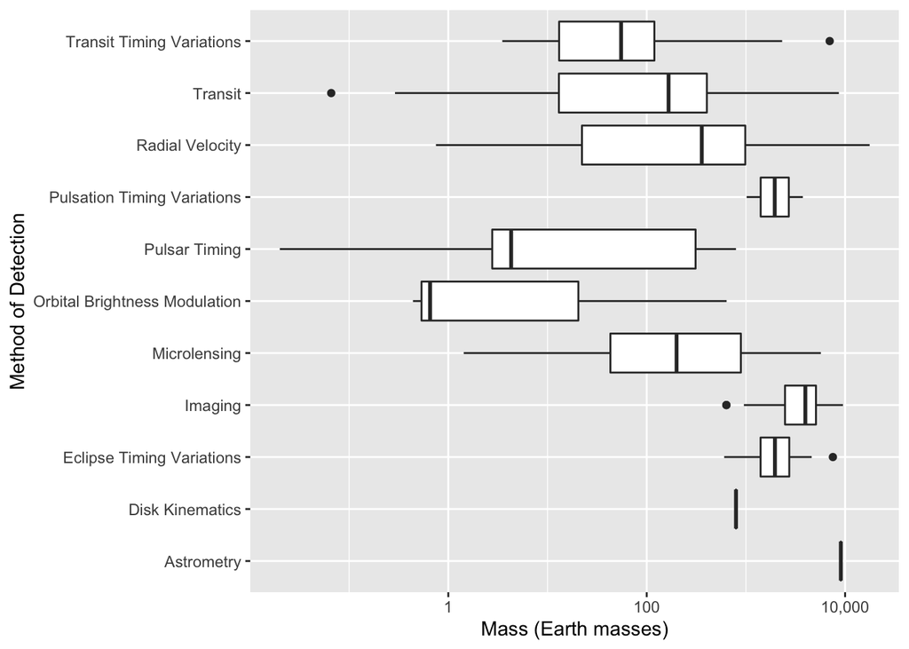

```r
## You may need to install the scales package if the next line causes an error
library(scales)

## Make the side-by-side boxplots
ggplot(exo, aes(x = method, y = mass)) +
  geom_boxplot() +
  ## (A) What does the following line do?
  scale_y_continuous(trans = "log10", label = comma) +
  xlab("Method of Detection") +
  ylab("Mass (Earth masses)") +
  ## (B) What does the following line do?
  coord_flip()
```

### Response

#### (A) effect of scale_y_continuous()

##### trans = “log10”

This code adjusts the scaling of the y-axis to a logarithmic function, instead of increasing by equal increments the scaling increases by powers.

##### label = comma

This addition to the code simply implements a comma to the value of 10,000 on the y (later to be flipped to the x) -axis.

#### (B) effect of coord_flip()

This code moves values of the x-axis to the y-axis and vice versa. It is useful in this case to spread out the previously clustered labels of the methods of detection.

### 8

Create a density plot of the variable `mass` from the exoplanet data set. Use different colors for the interior of the density and the boundary line. Describe the shape of exoplanet masses.

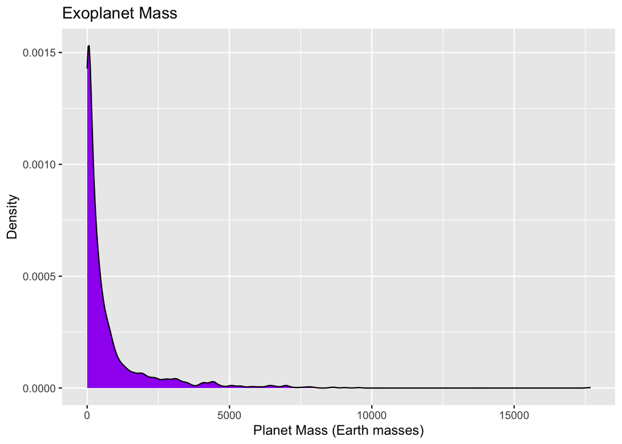

```r
ggplot(data=exo, aes(x=mass)) +
  geom_density(color="black", fill="purple") +
  xlab("Planet Mass (Earth masses)") +
  ylab("Density") +
  ggtitle("Exoplanet Mass")
```

### Response

Much like the original box plot, by itself this data is heavily skewed to the right.

Make a second density plot for the base-10 logarithm of masses instead. Describe the shape of the log-transformed exoplanet masses.

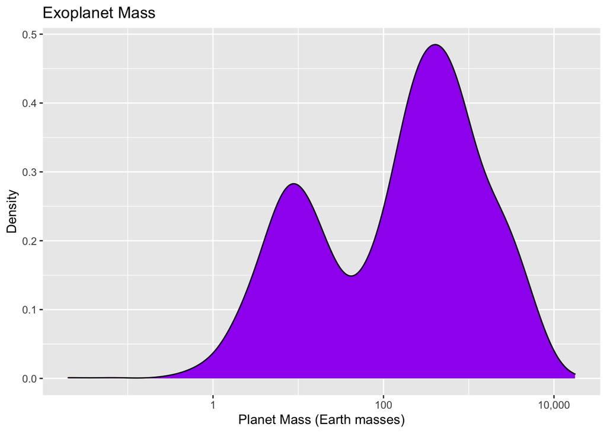

```r
ggplot(data=exo, aes(x=mass)) +
  geom_density(color="black", fill="purple") +
  scale_x_continuous(trans = "log10", label = comma) +
  xlab("Planet Mass (Earth masses)") +
  ylab("Density") +
  ggtitle("Exoplanet Mass")
```